# Notes on Chapter 5

The Caveman Coder

2025-12-30

# Areal Data

Areal or lattice data arise when a fixed domain is partitoned into a finite number of subregions at which outcomes are aggregated.

Examples: - The number of cancer cases in countries  
- The number of road accidents in provinces  
- The proportion of people living in poverty in census tracts

## Spatial neighborhood matrices

Example showing how neighbhors of several counties in the map of Pennsylvania, USA are coumputed using a neighborhood definition based on common boundaries of the counties.

Showing first the map of Pennsylvania obtained from the **SpatialEpi** package:

```r
library(SpatialEpi)
```

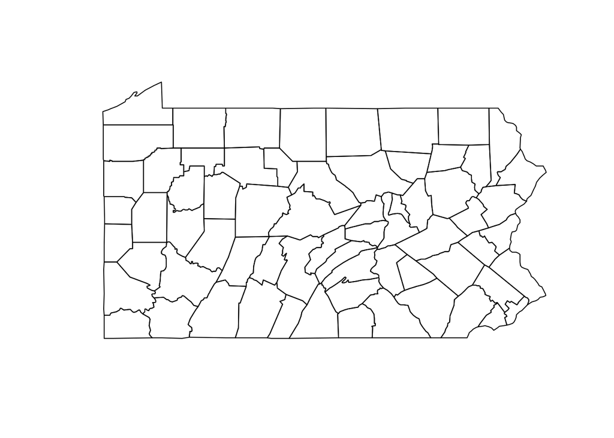

Map of Pennsylvania counties.

```r
map <- pennLC$spatial.polygon
plot(map)
```

Check what type of object `map` is:

```r
class(map)
```

```
## [1] "SpatialPolygons"
## attr(,"package")
## [1] "sp"
```

Obtaining the neighbors of each county in the map using the `poly2nb()` function from the **spdep** package:

```r
library(spdep)
```

```r
nb <- poly2nb(map)
head(nb)
```

```
## [[1]]
## [1] 21 28 67
##
## [[2]]
## [1]  3  4 10 63 65
##
## [[3]]
## [1]  2 10 16 32 33 65
##
## [[4]]
## [1]  2 10 37 63
##
## [[5]]
## [1]  7 11 29 31 56
##
## [[6]]
## [1] 15 36 38 39 46 54
```

The `poly2nb` function returns a neighbors list based on counties with contiguous boundaries. Each element in `nb` represents one county and contains the indices of its neighbors.

Showing the neighbors of specific counties of Pennsylvania, say neighbors of counties 2, 44, and 58:

```r
d <- data.frame(county = names(map), neigh = rep(0, length(map)))

head(d)
```

```
##      county neigh
## 1     adams     0
## 2 allegheny     0
## 3 armstrong     0
## 4    beaver     0
## 5   bedford     0
## 6     berks     0
```

```r
rownames(d) <- names(map)
```

Continuing… Creating a `SpatialPoligonsDataFrame` object from the original `map` and `d`:

```r
map <- SpatialPolygonsDataFrame(map, d, match.ID = TRUE)
```

Continuing… Setting `neigh` equal to 1 for counties that are neighbors of counties 2, 44, and 58 (otherwise, 0):

```r
map$neigh[nb[[2]]] <- 1
map$neigh[nb[[44]]] <- 1
map$neigh[nb[[58]]] <- 1
```

Adding coordinates to our data, plus a variable called `ID` that contains the `id` of the counties:

```r
coord <- coordinates(map)
map$long <- coord[, 1]
map$lat <- coord[, 2]
map$ID <- 1:dim(map@data)[1]
```

Plotting the map with `ggplot()`. First, convert `map` (which is a `SpatialPolygonsDataFrame` object) to a simple feature object of class `sf` using `st_as_sf()` function from the **sf** package:

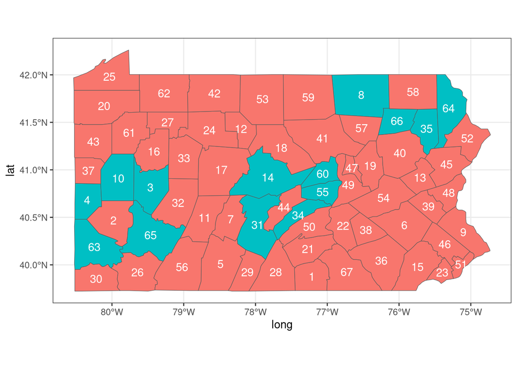

Neighbors of areas 2, 44, and 58 of Pennsylvania.

```r
library(sf)
library(ggplot2)

mapsf <- st_as_sf(map)

ggplot(mapsf) +
  geom_sf(aes(fill = as.factor(neigh))) +
  geom_text(aes(x = long, y = lat, label = ID), color = "white") +
  theme_bw() +
  guides(fill = "none")
```

## Standardized incidence ratio

This is the ratio of observed counts to the expected counts:
$$SIR_i = Y_i / E_i$$
The expected counts $E_i$ represent the total number of cases that one would expect if the population if area *i* behaved in a way the standard (or regional) population behaves.

$E_i$ can be calculated using:
$$E_i = \sum_{j=1}^{m} r_j^{(s)} n_j^{(i)}$$
where $r_j^{(s)}$ is the rate or number of cases divided by the population in $j$ in the standard population, and $n_j^{(i)}$ is the population stratum $j$ of area $i$.

The number of lung cancer cases and the population of Pennsylvania at country level stratified on race (white or non-white), gender (female or male), and age (under 40, 40-59, 60-69, and 70+) can be found in `pennLC$data`.

```r
head(pennLC$data)
```

```
##   county cases population race gender      age
## 1  adams     0       1492    o      f Under.40
## 2  adams     0        365    o      f    40.59
## 3  adams     1         68    o      f    60.69
## 4  adams     0         73    o      f      70+
## 5  adams     0      23351    w      f Under.40
## 6  adams     5      12136    w      f    40.59
```

Continuing…

```r
library(dplyr)
d <- pennLC$data |>
  group_by(county) |>
  summarize(Y = sum(cases))

head(d)
```

```
## # A tibble: 6 × 2
##   county        Y
##   <fct>     <int>
## 1 adams        55
## 2 allegheny  1275
## 3 armstrong    49
## 4 beaver      172
## 5 bedford      37
## 6 berks       308
```

Calculating the expected number of cases in each county using indirect standardization using the `expected()` function of **SpatialEpi**:

```r
# First sort the data
pennLC$data <- pennLC$data[order(
  pennLC$data$county,
  pennLC$data$race,
  pennLC$data$gender,
  pennLC$data$age
), ]

# Using the `expected()` function
E <- expected(
  population = pennLC$data$population,
  cases = pennLC$data$cases,
  n.strata = 16
)

head(E)
```

```
## [1]   69.62730 1182.42804   67.61012  172.55806   44.19013  300.70598
```

Adding vector `E` to our data frame `d` where the `E` elements correspond to the counties in `d$country` in the same order:

```r
d$E <- E[match(d$county, unique(pennLC$data$county))]
head(d)
```

```
## # A tibble: 6 × 3
##   county        Y      E
##   <fct>     <int>  <dbl>
## 1 adams        55   69.6
## 2 allegheny  1275 1182.
## 3 armstrong    49   67.6
## 4 beaver      172  173.
## 5 bedford      37   44.2
## 6 berks       308  301.
```

Note the the function `match()` was used to calculate the vector of the positions that match `d$county` in `unique(pennLC$data$county)`, which are the corresponding counties of `E`.

Computing the SIR values (ratio of the observed to the expected counts) using the formula explained above:

```r
d$SIR <- d$Y / d$E
head(d)
```

```
## # A tibble: 6 × 4
##   county        Y      E   SIR
##   <fct>     <int>  <dbl> <dbl>
## 1 adams        55   69.6 0.790
## 2 allegheny  1275 1182.  1.08
## 3 armstrong    49   67.6 0.725
## 4 beaver      172  173.  0.997
## 5 bedford      37   44.2 0.837
## 6 berks       308  301.  1.02
```

Adding the SIR info back to our `map` object:

```r
map <- merge(map, d)
```

Converting the `map` object (a `SpatialPolygonDataFrame` object) to an `sf` object, in preparation for plotting:

```r
mapsf <- st_as_sf(map)
```

Plotting the map using `ggplot()` (now with SIR info used to color the counties):

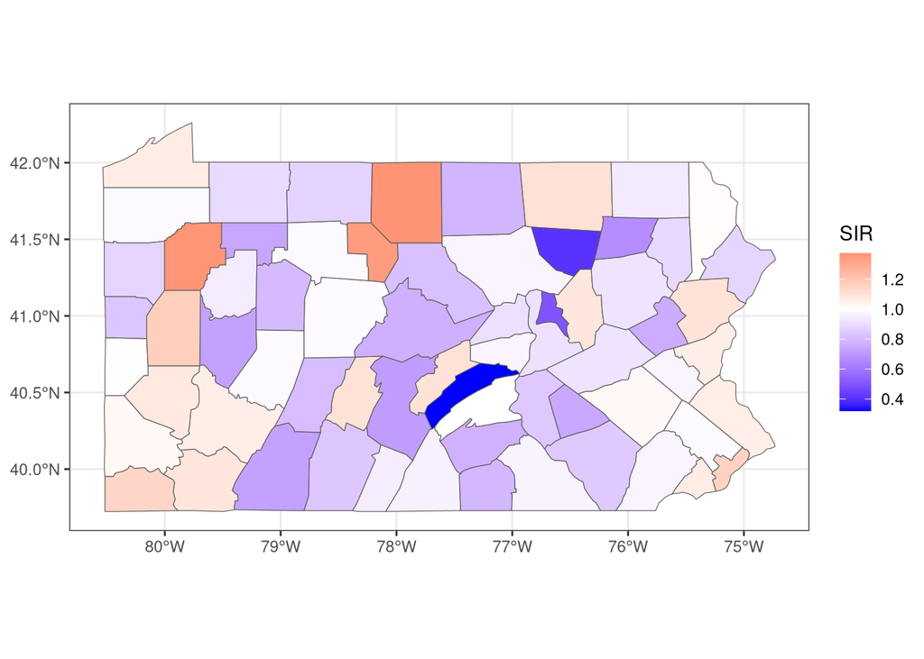

SIR of lung cancer in Pennsylvania counties.

```r
mapsf |> ggplot() +
  geom_sf(aes(fill = SIR)) +
  scale_fill_gradient2(
    midpoint = 1,
    low = "blue",
    mid = "white",
    high = "red"
  ) +
  theme_bw()
```

The white color fill represents counties where the number of lung cancer cases observed match the number of expected cases. In counties where SIR > 1 or the number of lung cancer cases observed is higher than the number of expected cases, the fill color is reddish. In counties where SIR < 1 or the number of observed lung cancer cases is lower than that of expected cases, the fill color is bluish.

## Spatial small area disease risk estimation

In regions with small populations or rare diseases are expected, the expected counts may be very low, and this leads to misleading SIRs.

A popular spatial model that we can use for this case is the BYM model (Besag-York-Mollie). In this model, the spatial random effect is assigned a Conditional Autoregressive distribution which wmoothes the data according to certain neighborhood structure that specifies that two areas are neighbors if they share a common boundary.

In **R-INLA** the BYM model can be accessed by specifying the formula in this manner:

```r
formula <- Y ~
  f(idareeau, model = "besag", graph = g, scale.model = TRUE) +
  f(idareav, model = "iid")
```

In this formula, the option `scale.model = TRUE` is used to make the precision parameter of models with different CAR priors comparable.

A new parametrization of the BYM model called BYM2 was proposed by Simpson et al. in 2017. In **R-INLA**, the BMY2 model can be specified by creating the formula like this:

```r
formula <- Y ~ f(idarea, model = "bym2", graph = g)
```

### Spatial modeling of lung cancer in Pennsylvania

Using the BYM2 model to calculate relative risks of lung cancer in the Pennsylvania counties:

First we define the `idarea` variable (typically a vector `c(1, 2, ..., I)` where `I` is the number of counties).

```r
map$idarea <- 1:nrow(map@data)
```

Then we define a PC prior for the marginal precision…

```r
prior <- list(
  prec = list(
    prior = "pc.prec",
    param = c(0.5 / 0.31, 0.01)
  ),
  phi = list(
    prior = "pc",
    param = c(0.5, 2 / 3)
  )
)
```

Computing the object `g` with the neighborhood matrix that will be used in the spatially structured effect (create first a neighbors list `nb` using `poly2nb()` then use `nb2INLA()` to convert it to a neighborhood representation matrix required by the **R-INLA** package):

```r
# creation of neighbors list nb
nb <- poly2nb(map)
head(nb)
```

```
## [[1]]
## [1] 21 28 67
##
## [[2]]
## [1]  3  4 10 63 65
##
## [[3]]
## [1]  2 10 16 32 33 65
##
## [[4]]
## [1]  2 10 37 63
##
## [[5]]
## [1]  7 11 29 31 56
##
## [[6]]
## [1] 15 36 38 39 46 54
```

```r
# creation of neighborhood representation matrix
library(INLA)
```

```r
nb2INLA("map.adj", nb)
g <- inla.read.graph(filename = "map.adj")
```

Specifying the formula:

```r
formula <- Y ~ f(idarea, model = "bym2", graph = g, hyper = prior)
```

Fitting the model by calling the `inla()` function:

```r
res <- inla(
  formula,
  family = "poisson",
  data = map@data,
  E = E,
  control.predictor = list(compute = TRUE)
)
```

The parameter `control.predictor = TRUE` means that we set the `control.predictor` parameter equal to `list(compute = TRUE`) to compute the posteriors of the predictions.

Checking the results:

```r
summary(res)
```

```
## Time used:
##     Pre = 3.87, Running = 0.206, Post = 0.0678, Total = 4.14
## Fixed effects:
##               mean    sd 0.025quant 0.5quant 0.975quant   mode kld
## (Intercept) -0.051 0.017     -0.085   -0.051     -0.018 -0.051   0
##
## Random effects:
##   Name     Model
##     idarea BYM2 model
##
## Model hyperparameters:
##                         mean     sd 0.025quant 0.5quant 0.975quant    mode
## Precision for idarea 129.018 53.408     55.223  118.991    261.542 101.319
## Phi for idarea         0.478  0.226      0.089    0.472      0.892   0.422
##
## Marginal log-Likelihood:  -225.07
##  is computed
## Posterior summaries for the linear predictor and the fitted values are computed
## (Posterior marginals needs also 'control.compute=list(return.marginals.predictor=TRUE)')
```

Looking at the summaries of relative risks:

```r
head(res$summary.fitted.values)
```

```
##                          mean         sd 0.025quant  0.5quant 0.975quant
## fitted.Predictor.01 0.8671787 0.06817295  0.7377184 0.8656146   1.005949
## fitted.Predictor.02 1.0679486 0.02863808  1.0130338 1.0675126   1.125342
## fitted.Predictor.03 0.9114850 0.06855087  0.7750962 0.9123334   1.044168
## fitted.Predictor.04 0.9978089 0.05794622  0.8880462 0.9963861   1.115806
## fitted.Predictor.05 0.9092835 0.07064648  0.7749700 0.9075990   1.053877
## fitted.Predictor.06 0.9954243 0.04744172  0.9069826 0.9937621   1.093222
##                          mode
## fitted.Predictor.01 0.8629461
## fitted.Predictor.02 1.0666395
## fitted.Predictor.03 0.9150816
## fitted.Predictor.04 0.9937287
## fitted.Predictor.05 0.9049880
## fitted.Predictor.06 0.9903857
```

Adding columns to the results in preparation for plotting:

```r
map$RR <- res$summary.fitted.values[, "mean"]
map$LL <- res$summary.fitted.values[, "0.025quant"]
map$UL <- res$summary.fitted.values[, "0.975quant"]

summary(map@data[, c("RR", "LL", "UL")])
```

```
##        RR               LL               UL
##  Min.   :0.8412   Min.   :0.7171   Min.   :0.9454
##  1st Qu.:0.9140   1st Qu.:0.7814   1st Qu.:1.0479
##  Median :0.9446   Median :0.8195   Median :1.0834
##  Mean   :0.9550   Mean   :0.8333   Mean   :1.0884
##  3rd Qu.:0.9905   3rd Qu.:0.8795   3rd Qu.:1.1322
##  Max.   :1.1469   Max.   :1.0897   Max.   :1.2579
```

Code for generating plot objects:

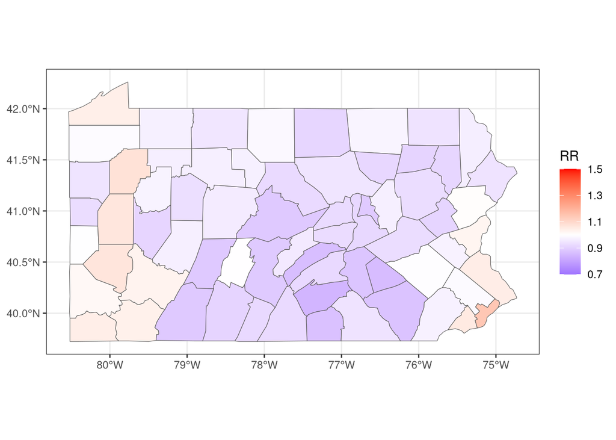

```r
mapsf <- st_as_sf(map)

gRR <- mapsf |>
  ggplot() +
  geom_sf(aes(fill = RR)) +
  scale_fill_gradient2(
    midpoint = 1,
    low = "blue",
    mid = "white",
    high = "red",
    limits = c(0.7, 1.5)
  ) +
  theme_bw()

gRR
```

for gLL:

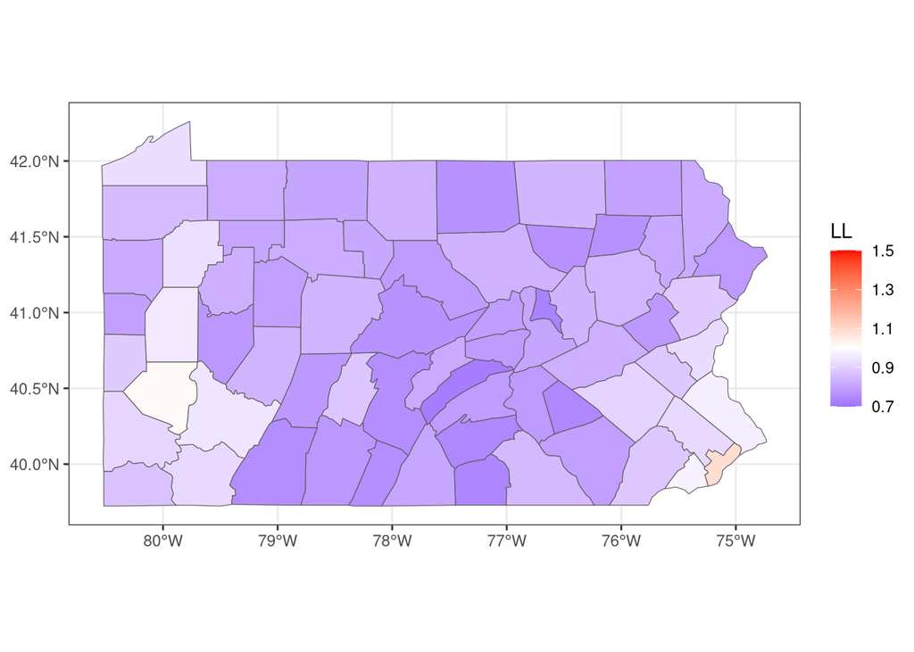

```r
gLL <- mapsf |>
  ggplot() +
  geom_sf(aes(fill = LL)) +
  scale_fill_gradient2(
    midpoint = 1,
    low = "blue",
    mid = "white",
    high = "red",
    limits = c(0.7, 1.5)
  ) +
  theme_bw()

gLL
```

for gUL:

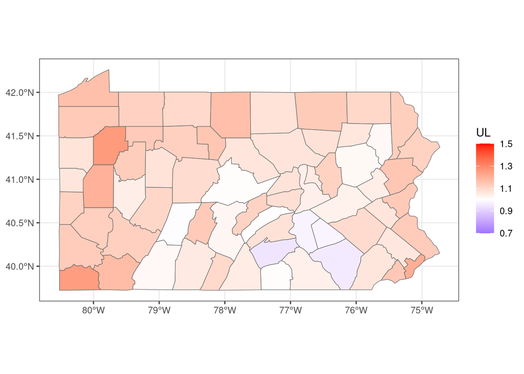

```r
gUL <- mapsf |>
  ggplot() +
  geom_sf(aes(fill = UL)) +
  scale_fill_gradient2(
    midpoint = 1,
    low = "blue",
    mid = "white",
    high = "red",
    limits = c(0.7, 1.5)
  ) +
  theme_bw()

gUL
```

Plotting the three objects side-by-side using the `plot_grid()` function from the **cowplot** package:

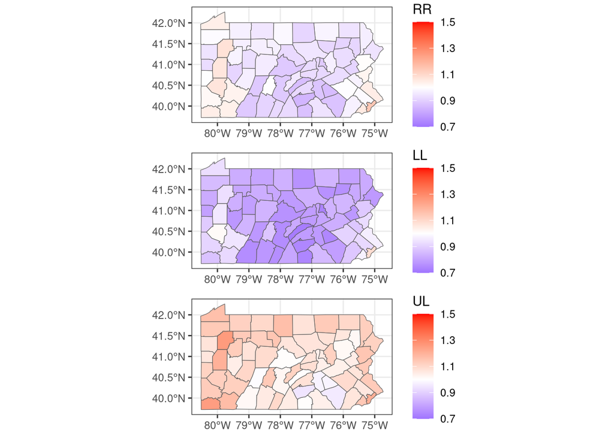

```r
library(cowplot)
plot_grid(gRR, gLL, gUL, ncol = 1)
```

Of course, we could have used `facet_grid()` or `facet_wrap()` to achieve the same effect.

Looking at the summary of random effects in the results:

```r
head(res$summary.random$idarea)
```

```
##   ID        mean         sd  0.025quant    0.5quant 0.975quant        mode
## 1  1 -0.09453287 0.07747179 -0.25003136 -0.09348696 0.05537995 -0.09342745
## 2  2  0.11619322 0.03119691  0.05563481  0.11597013 0.17802485  0.11597022
## 3  3 -0.04554969 0.07506966 -0.20402974 -0.04153169 0.09121243 -0.02990419
## 4  4  0.04682801 0.05868013 -0.06865051  0.04683429 0.16227314  0.04683597
## 5  5 -0.04718632 0.07596917 -0.19976819 -0.04634362 0.10108478 -0.04627867
## 6  6  0.04526608 0.04946125 -0.04946364  0.04440019 0.14471179  0.04434384
##            kld
## 1 6.383590e-08
## 2 1.310381e-08
## 3 4.912547e-07
## 4 1.626087e-08
## 5 9.112157e-08
## 6 6.612424e-08
```

Adding another column to the results to make plotting easier:

```r
mapsf$re <- res$summary.random$idarea[1:67, "mean"]
head(mapsf)
```

```
## Simple feature collection with 6 features and 13 fields
## Geometry type: POLYGON
## Dimension:     XY
## Bounding box:  xmin: -80.51776 ymin: 39.72889 xmax: -75.53303 ymax: 41.1441
## Geodetic CRS:  +proj=longlat
##              county neigh      long      lat ID    Y          E       SIR
## adams         adams     0 -77.21550 39.87776  1   55   69.62730 0.7899200
## allegheny allegheny     0 -79.97980 40.46986  2 1275 1182.42804 1.0782897
## armstrong armstrong     1 -79.46558 40.81654  3   49   67.61012 0.7247435
## beaver       beaver     1 -80.34774 40.68327  4  172  172.55806 0.9967660
## bedford     bedford     0 -78.48906 40.01033  5   37   44.19013 0.8372910
## berks         berks     0 -75.92717 40.41920  6  308  300.70598 1.0242563
##           idarea        RR        LL       UL                       geometry
## adams          1 0.8671787 0.7377184 1.005949 POLYGON ((-77.4467 39.96954...
## allegheny      2 1.0679486 1.0130338 1.125342 POLYGON ((-80.14534 40.6742...
## armstrong      3 0.9114850 0.7750962 1.044168 POLYGON ((-79.21142 40.9091...
## beaver         4 0.9978089 0.8880462 1.115806 POLYGON ((-80.1568 40.85189...
## bedford        5 0.9092835 0.7749700 1.053877 POLYGON ((-78.38063 39.7288...
## berks          6 0.9954243 0.9069826 1.093222 POLYGON ((-75.53303 40.4508...
##                    re
## adams     -0.09453287
## allegheny  0.11619322
## armstrong -0.04554969
## beaver     0.04682801
## bedford   -0.04718632
## berks      0.04526608
```

Visualizing the posterior mean of the random effects:

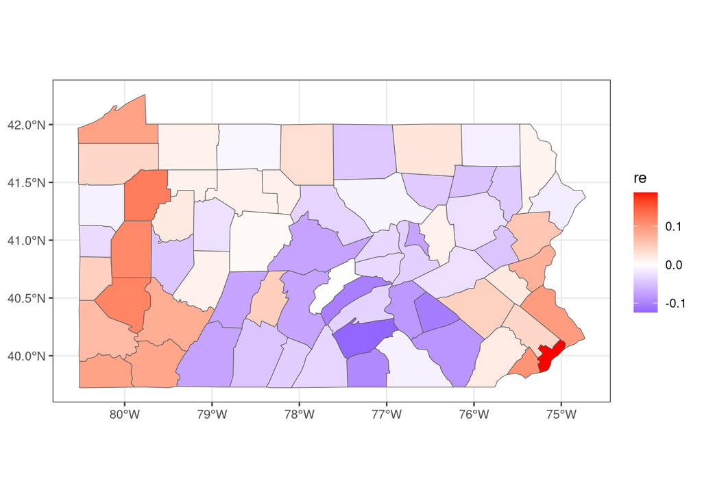

Posterior mean of the BYM2 random effect.

```r
mapsf |> ggplot() +
  geom_sf(aes(fill = re)) +
  scale_fill_gradient2(
    midpoint = 0,
    low = "blue",
    mid = "white",
    high = "red"
  ) +
   theme_bw()
```